# Introduction to Data Science (Talk influenced by Skylar Versage)

# Hi! My name is Aritro Majumdar

- Graduate from Galvanize Data Science Immersive Program (Feb 2018)
- Junior at ASU
- Data Science Intern @ Kono.store

# Super Basic Intro to Talk Question:

## What is Data Science?

- Coding Statistical Analysis
- Machine Learning
- Deep Learning

# History:

- Started as Statistical Analysis using SAS (base cost $9000)
- When computing power increased and became more accessible, statisticians used programming languages like R (free) and Python (free) to solve complex problems then data science was born

# 1. Coding Statistical Analysis:

- Hypothesis testing
- ANOVA
- A/B Testing

# Examples:

## Hypothesis Testing:

```python
#Taken from http://hamelg.blogspot.com/2015/11/python-for-data-analysis-part-24.html

#One Sample T-Test: Test whether the average age of voters Minnesota differs from the population
import numpy as np
import pandas as pd
import scipy.stats as stats
import matplotlib.pyplot as plt
import math

np.random.seed(6)

population_ages1 = stats.poisson.rvs(loc=18, mu=35, size=150000)
population_ages2 = stats.poisson.rvs(loc=18, mu=10, size=100000)
population_ages = np.concatenate((population_ages1, population_ages2))

minnesota_ages1 = stats.poisson.rvs(loc=18, mu=30, size=30)
minnesota_ages2 = stats.poisson.rvs(loc=18, mu=10, size=20)
minnesota_ages = np.concatenate((minnesota_ages1, minnesota_ages2))

print('Mean Population Ages: ' + str(population_ages.mean()))
print('Mean Minnesota Ages: ' + str(minnesota_ages.mean()))

stats.ttest_1samp(a= minnesota_ages, popmean= population_ages.mean())
```

```
Mean Population Ages: 43.000112
Mean Minnesota Ages: 39.26
```

```
Ttest_1sampResult(statistic=-2.5742714883655027, pvalue=0.013118685425061678)
```

# 2. Machine Learning:

## Reinforcment Learning:

- React to environment

## Examples:

- AlphaGo
- DeepBlue
- Video Games

[figure not shown]

## Supervised Learning:

- Regression
- Classification

Refers to a set of samples where the desired output signals (labels) are already known. The training set then becomes the basis for predicting unknown similar sets

This is really the bread and butter of ML right now

## This is broken down into two categories regression and classification

[figure not shown]

One predicts a **continuous** dependent variable, the other a **discrete** dependent variable

## Regression Examples:

- Stock prices
- House price sales
- Temp forecasting

### Popular Regression Algorithms:

- Old Trusty -- Linear Regression

[figure not shown]

- KNN
- Random Forest
- Graient Boosting (very similiar to classification with some tweaks)

## Classification Examples:

[figure not shown]

### Popular Classification Algorithms

- Logistic Regression

[figure not shown]

- KNN

[figure not shown]

- Random Forest

[figure not shown]

- Gradient Boosted Trees (XGB, CATBoost, etc)

[figure not shown]

# Examples:

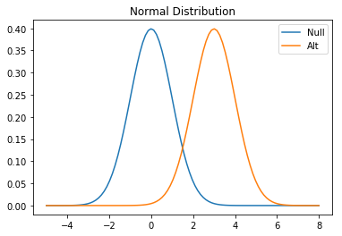

```python
# Scipy allows for workign with popular probability distributions, as well as hypothesis testing
import scipy.stats as scs
import matplotlib.pyplot as plt

%matplotlib inline

#create the Random Varible X with a mean of 0 and standard deviation of 1
null = scs.norm(loc=0,scale=1)
alt = scs.norm(loc=3,scale=1)

x = np.linspace(-5,8, 100)

plt.plot(x, null.pdf(x), label='Null')
plt.plot(x, alt.pdf(x), label='Alt')
plt.title('Normal Distribution')
plt.legend()
plt.show()
```

```python
import pandas as pd
#Pandas -- the go to for data clean up and quick plotting
df = pd.read_csv('http://archive.ics.uci.edu/ml/machine-learning-databases/iris/iris.data',
                      names=['sepal_length', 'sepal_width', 'petal_length', 'petal_width', 'species'])

df.describe().T
```

|  | count | mean | std | min | 25% | 50% | 75% | max |
| --- | --- | --- | --- | --- | --- | --- | --- | --- |
| sepal_length | 150.0 | 5.843333 | 0.828066 | 4.3 | 5.1 | 5.80 | 6.4 | 7.9 |
| sepal_width | 150.0 | 3.054000 | 0.433594 | 2.0 | 2.8 | 3.00 | 3.3 | 4.4 |
| petal_length | 150.0 | 3.758667 | 1.764420 | 1.0 | 1.6 | 4.35 | 5.1 | 6.9 |
| petal_width | 150.0 | 1.198667 | 0.763161 | 0.1 | 0.3 | 1.30 | 1.8 | 2.5 |

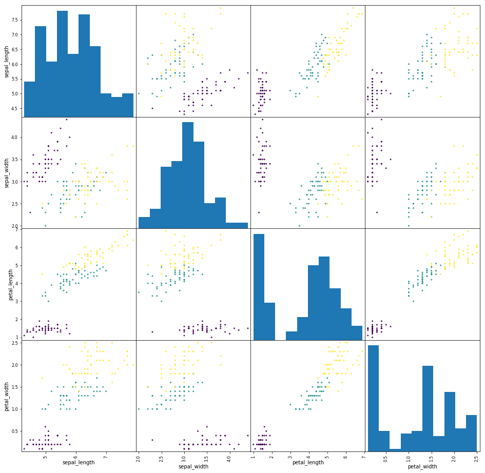

```python
from pandas.plotting import scatter_matrix

scatter_matrix(df,
               alpha=0.9,
               c=df.species.astype('category').cat.codes,
               figsize=(16,16))

plt.show()
```

```python
from sklearn.linear_model import LogisticRegression

clf = LogisticRegression(C=1000)
clf.fit(X,y)
print(clf.intercept_)
clf.coef_
```

```
[-1.09862136]
```

```
array([[-0.03796945,  1.58452679,  0.41810531,  0.62884559,  0.50742546]])
```

# 2. Deep Learning:

- Artificial Neural Newworks
  - Generative Adversarial Networks (GAN)
  - Convolutional Neural Network (CNN)
  - Recurrent Neural Network (RNN)
  - Keras

# Examples:

# Sorry, I don't have any! :'(

[figure not shown]

# Deep Learning Resources;

- https://machinelearningmastery.com/tutorial-first-neural-network-python-keras/
- https://www.datacamp.com/courses/deep-learning-in-python

# Data Science Flow Overview:

[figure not shown]

# Questions?

# Thanks You! :)